# Theographs

Welcome to my Theographs page! Here, I’m using my dataviz skills to explore aspects of theology, the Biblical texts and church life, and vice versa. Clicking on the {Code} buttons next to each plot will show the code I wrote to build it. Happy browsing, and if you like what you see, [get in touch](https://twitter.com/cararthompson)!

## 2020-08 - Divine Blessedness

This month, I had a stab at reworking a graph from the 16th century which is part of Polanus’ Partitiones Theologicae, a series of graphs exploring the attributes of God by organising them into hierarchical groupings. The [full set of graphs](https://books.google.co.uk/books?id=9AFcAAAAQAAJ&printsec=frontcover&redir_esc=y#v=onepage&q&f=false) is pretty mind-boggling, but here’s the original version of the one I tackled:

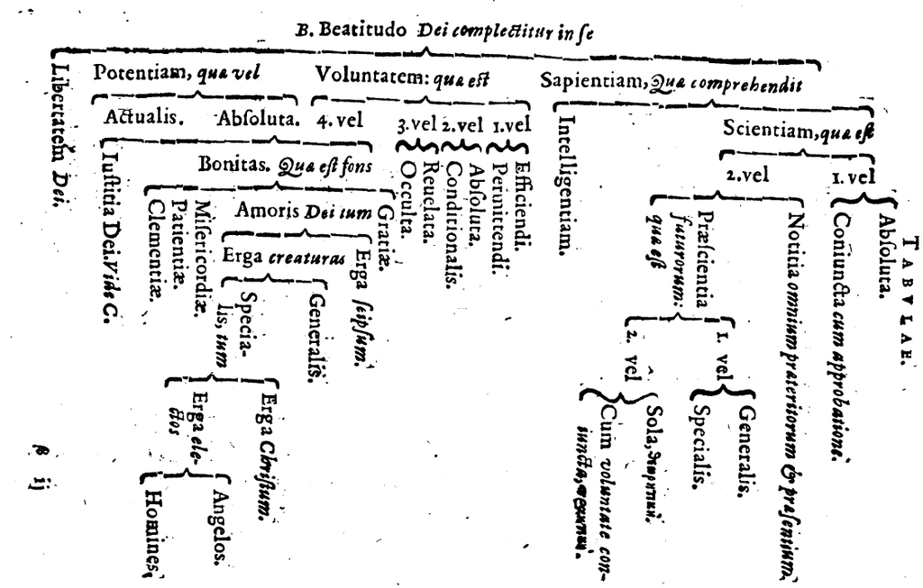

And here’s how I redesigned it. Each time the page is loaded, the nodes (dots) are in a different place, but their relationships remain the same. Clicking on a node will highlight the ones that are directly connected to it. You can also drag the nodes around, for fun or to reorganise them. Not sure whether the added movement creates further theological difficulties, though!

```r
vis.links <- read.csv("data/202008_polanus_edges.csv", header = T,
                      stringsAsFactors = F)

vis.nodes <- read.csv("data/202008_polanus_nodes.csv", header = T,
                      stringsAsFactors = F) %>%
  mutate(overarching = factor(overarching),
         shape = "dot",
         shadow = T,
         label = characteristic,
         size = level * 4,
         borderwigth = 2,
         font.size = level + 28,
         color.border = "black",
         color.highlight.border = "slategrey")

vis.nodes$color.background <- vis.nodes$color.highlight.background <-
  c(viridis(5)[5:1])[vis.nodes$overarching]

visNetwork(vis.nodes, vis.links,
           main = list(text = "Doctrine Of God Contained Within Divine Blessedness <br> Polanus, 1590",
                       style = "font-family:Raleway;color:#666561;font-size:20px;text-align:center;"),
           footer = list(text = "Graphic: @crthompson | Source: Polanus' Partitiones Theologicae, 1590",
                         style = "font-family:Raleway;color:#666561;font-size:10px;text-align:center;")) %>%
  visOptions(highlightNearest = list(enabled = T, degree = 1, hover = F),
             width = "100%") %>%
  visInteraction(dragNodes = T, dragView = F, zoomView = F)
```

[interactive chart not shown]